# TP 3 : Fonction de coût - Correction Exercice 10

## Étude numérique

**Attention** : Dans toutes cette correction, les fonctions ont été testées très brièvement à chaque fois. Lorsque vous codez, pensez bien à faire un test après chaque bout de code écrit.

**De plus, aucune des figure ici n’a ni légende, ni titre, ni noms d’axes. Il ne faut JAMAIS faire ça !**

On se place dans le cadre suivant :

- $X_1,X_2,X_3 \sim_{i.i.d} Bin(N,p)$, avec $N = 100$
- On met un prior sur $p$ dans la famille conjuguée pour la loi Binômiale, et uniforme, i.e. $p \sim Beta(1,1)$

On peut déjà écrire le coût ponctuel sur une nouvelle donnée :

```r
Lp = function(xnew,d){
  return(300*(d-xnew)*(d>xnew)+100*(xnew-d)*(d<xnew))
  #300 euros par chambre si la décision d est plus grande que le nombre de chambres necessaire xnew (sur-reservation)
  #100 euros par chambre si la décision d est plus petite que le nombre de chambres nécessaire xnew (sous-reservation)
}
Lp(78,10)#test avec valeurs arbitraires
```

```
[1] 6800
```

Pour calculer le coût moyen sur une nouvelle donnée de paramètre $p$, il suffit de moyenner les coûts pour obtenir la fonction prédictive de coût :

```r
L = function(p,d,N,n = 100){
  #n : param monte carlo pour calculer l'espérance
  x = rbinom(n,N,p)#on simule une nouvelle donnée de loi Bin(N,p)
  l = sapply(x,Lp,d = d)
  return(mean(l))#on calcule le cout moyen
}
L(0.8,10,100)#test avec valeurs arbitraires
```

```
[1] 6987
```

On peut ensuite calculer le coût à posteriori (i.e. en tirant $p$ sous la loi à posteriori), en considérant le coût moyen sous le posterior :

```r
rho = function(hyperparam,d,N,n = 100){
  #n : param monte carlo pour calculer l'espérance
  pvec = rbeta(n,hyperparam[1],hyperparam[2])
  uvec = sapply(pvec,L,d = d,n= n,N = N)
  return(mean(uvec))#on renvoie le cout moyen
}
rho(c(80,10),10,100)#test avec valeurs arbitraires
```

```
[1] 7944.07
```

Il ne reste plus qu’à minimiser le coût, sur toutes les décisions possibles :

```r
minim_post = function(hyperparam,N,n = 100){
  dvec = 0:N
  y = sapply(dvec,rho,hyperparam = hyperparam,N = N,n = n)
  dstar= dvec[which.min(y)]
  return(list(decision = dstar,cout = min(y)))
}
minim_post(c(10,10),100)#test avec valeurs arbitraires
```

```
$decision
[1] 41

$cout
[1] 1308.4
```

On peut maintenant utiliser les données de l’énoncé.

```r
n = 100#param de Monte-Carlo
N = 100#param de binomial
D = c(79,85)#données de l'énoncé
a0 = 1
b0 = 1
```

On peut utiliser le fait que le prior est dans une famille conjuguée pour la loi Binômiale, et calculer les hyperparamètres de la loi à posteriori :

```r
hyperparam_post  = c(a0+sum(D),b0+length(D)*N-sum(D))#comme on a vu en cours : savoir refaire tous les calculs !
hyperparam_post
```

```
[1] 165  37
```

On peut enfin chercher numériquement la décision optimale :

```r
lstar = minim_post(hyperparam_post,N,100)
lstar
```

```
$decision
[1] 78

$cout
[1] 594.66
```

## Étude théorique

Maintenant regardons du côté de la théorie : - Le coût prédictif, peut se calculer en fonction de $\theta$ :

$$\begin{eqnarray}
L(\theta,d) &= &\mathbb{E}_{X_{n+1} \sim \pi(X|\theta) }\Big[ 300(d-X_{n+1}) 1\!\!1_{d>X_{n+1}}+100(X_{n+1}-d) 1\!\!1_{d<X_{n+1}}\Big]
\end{eqnarray}$$

- Le coût a posteriori revient à intégrer la fonction de coût contre la loi a posteriori, ce qui donne :
  $$\begin{eqnarray}
  \rho_\pi(d) &= &\mathbb{E}_{\theta \sim \pi(\theta|\mathcal{D})} \Big[L(\theta,d) \Big]
  \\ & = & \mathbb{E}_{X_{n+1} \sim \pi(X|\mathcal{D}) }\Big[ 300(d-X_{n+1}) 1\!\!1_{d>X_{n+1}}+100(X_{n+1}-d) 1\!\!1_{d<X_{n+1}}\Big]
  \end{eqnarray}$$

En regardant l’accroissement de cette expression par rapport à $d$, on obtient :
$$\rho(d+1)-\rho(d) =300 \pi(X_{n+1}\leq d|\mathcal{D}) -100 \pi(X_{n+1}>d|\mathcal{D}) .$$
En cherchant le signe de ce terme, on obtient
$$\rho(d+1) \geq \rho(d) \Leftrightarrow 3\pi(X_{n+1}\leq d|\mathcal{D}) \geq \pi(X_{n+1}>d|\mathcal{D}) = 1-\pi(X_{n+1}\leq d|\mathcal{D})$$
Et enfin :
$$\rho(d+1) \geq \rho(d) \Leftrightarrow \pi(X_{n+1}\leq d|\mathcal{D}) \geq \frac 1 4$$
La décision optimale $d^\star$ correspond au plus petit $d$ qui vérifie $\pi(X_{n+1}\leq d|\mathcal{D}) \geq \frac 1 4$, donc la décision optimale $d^\star$ **correspond au premier quartile de la loi prédictive**

Il n’y a plus qu’à vérifier numériquement :

```r
library(rmutil)
ap = hyperparam_post[1]
bp = hyperparam_post[2]
mp = ap/(ap+bp)
sp = ap+bp
dstar = qbetabinom(1/4,size = N,mp,sp)#parametree de facon particuliere
dstar
```

```
[1] 79
```

```r
pbetabinom(c(78,79),N,mp,sp)
```

```
[1] 0.2427661 0.3098973
```

Enfin, il est intéressant d’observer les coûts théoriques et estimés (on sépare en les coûts de sur et sous réservation)

```r
xnew = rbetabinom(10000,size = N,mp,sp)#on simule la loi a posteriori
dvec = 0:N
ysous = sapply(dvec, function(d){mean(100*(xnew-d)*(d<xnew))})#cout de sous réservation
ysur =  sapply(dvec, function(d){mean(300*(d-xnew)*(d>xnew))})#cout de sur réservation
plot(dvec,ysous,"l")
lines(dvec,ysur,col = "blue")
```

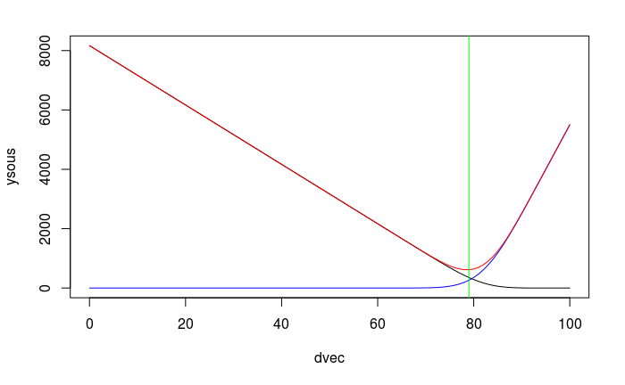

```r
lines(dvec,ysur+ysous,col = "red")
abline(v = dstar,col = "green")
```

On peut aussi s’interesser aux différenciées (“dérivées discrètes”) de ces fonctions de coût, qui doivent se croiser pour annuler la dérivée du coût global. Dans ce cas, c’est simple, il s’agit des fonctions de répartitions.

```r
plot(dvec[-1]-1,-diff(ysous),"l")
lines(dvec[-1]-1,diff(ysur),"l",col = "blue")
```

```r
lines(dvec,300*pbetabinom(dvec,N,mp,sp),col = "red")
lines(dvec,100*(1-pbetabinom(dvec,N,mp,sp)),col = "orange")
```

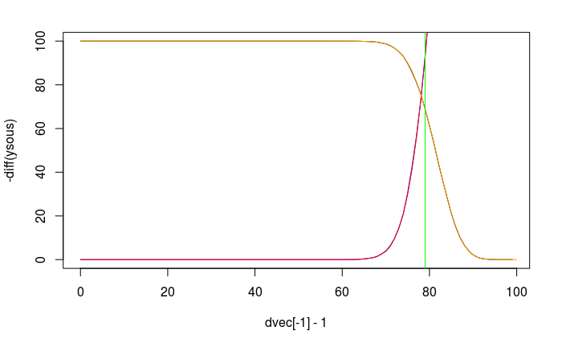

```r
abline(v = dstar,col = "green")
```

## Étude avec coût different.

Il suffit de changer la fonction de coût, et de recommencer.

```r
Lp = function(xnew,d){
  return(1000*(d>xnew)+100*(xnew-d)*(d<xnew))
  #1000 euros si la décision d est plus grande que le nombre de chambres necessaire xnew (sur-reservation)
  #100 euros par chambre si la décision d est plus petite que le nombre de chambres nécessaire xnew (sous-reservation)
}
lstar = minim_post(hyperparam_post,N,200)
lstar
```

```
$decision
[1] 80

$cout
[1] 601.4175
```

On peut l’observer sur un graphe

```r
ysous = sapply(dvec, function(d){mean(100*(xnew-d)*(d<xnew))})#cout de sous réservation
ysur =  sapply(dvec, function(d){mean(1000*(d>xnew))})#cout de sous réservation
plot(dvec,ysous,"l")
lines(dvec,ysur,col = "blue")
```

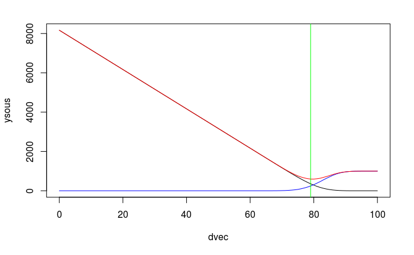

```r
lines(dvec,ysur+ysous,col = "red")
abline(v = dstar,col = "green")
```

Ainsi que les dérivées discrètes :

```r
plot(dvec[-1]-1,-diff(ysous),"l")
lines(dvec[-1]-1,diff(ysur),col = "blue")
```

```r
lines(dvec,1000*dbetabinom(dvec,N,mp,sp),col = "red")
lines(dvec,100*(1-pbetabinom(dvec,N,mp,sp)),col = "orange")
```

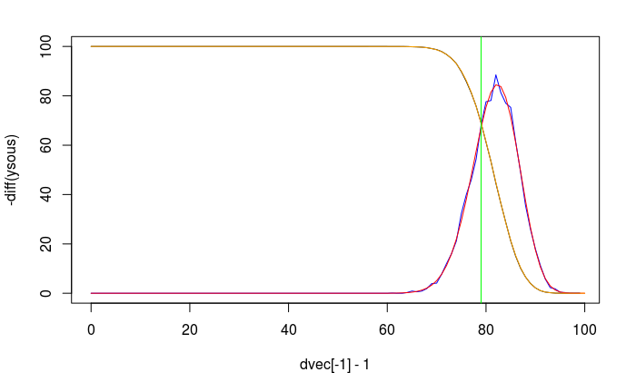

```r
abline(v = dstar,col = "green")
```

## Améliorations

On peut voir que la durée d’exécution est bien grande au vue du problème. De plus, si on cherche à représenter le coût, on observe la chose suivante :

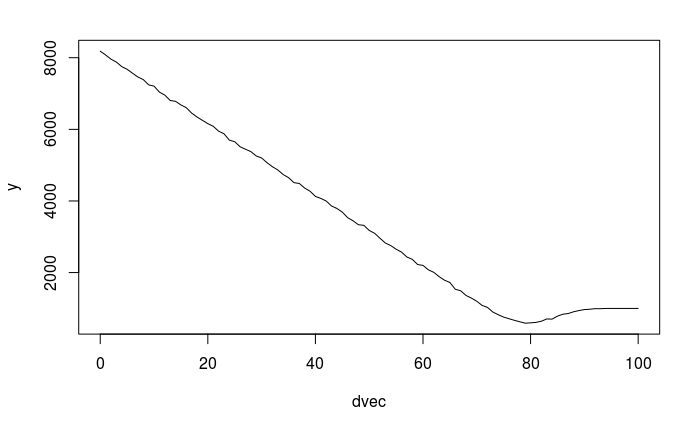

```r
dvec = 0:N
y = sapply(dvec,rho,hyperparam = hyperparam_post,N = N,n = n)
plot(dvec,y,"l")
```

Et en zoomant auprès du minimum :

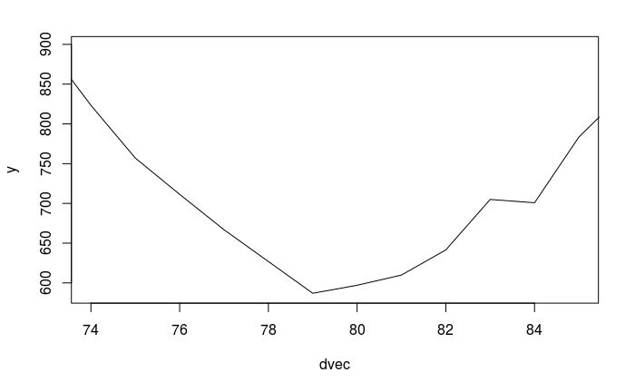

```r
plot(dvec,y,"l",xlim = c(74,85),ylim = range(y[74:85]))
```

On voit bien les fluctuations dues aux estimations Monte-Carlo des espérances, qui rendent difficiles de trouver le minimum. Et c’est bien pire lorsque le posterior n’est pas concentré :

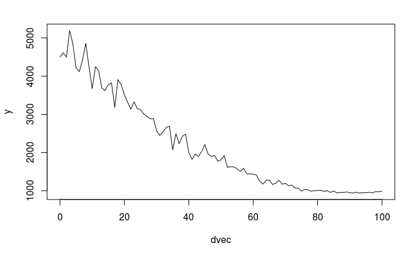

```r
dvec = 0:N
y = sapply(dvec,rho,hyperparam = c(1,1),N = N,n = 100)
plot(dvec,y,"l")
```

Et en zoomant

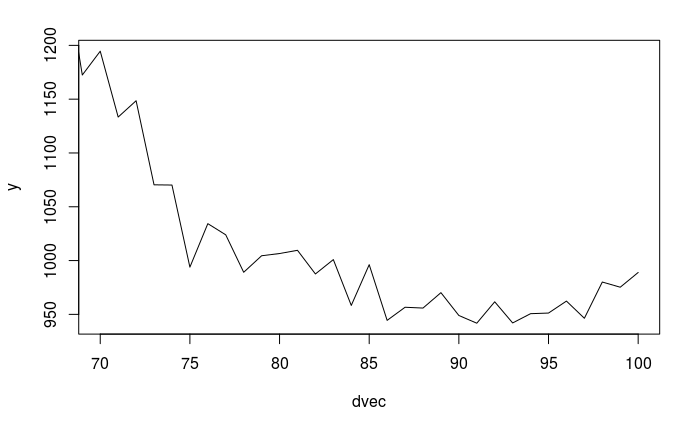

```r
plot(dvec,y,"l",xlim = c(70,100),ylim = range(y[70:100]))
```

*vous pouvez vous amusez avec un posterior uniforme à reprendre la première fonction de coût, et voir comment cela change le résultat ici…*

Il faut donc comprendre que l’on a ici trois problèmes : - Le code est long pour des mauvaises estimations - L’estimation MC n’est pas optimale, vue que seule la loi prédictive nous intéresse, on pourrait tirer un $P$ différent pour chaque $X$. - Comme un nouveau échantillon Monte-Carlo est tiré pour chaque décision testée, il est difficile de minimiser le coût. C’est pratique pour observer la variabilité due aux estimations MC, mais pas terrible pour obtenir la décision optimale.

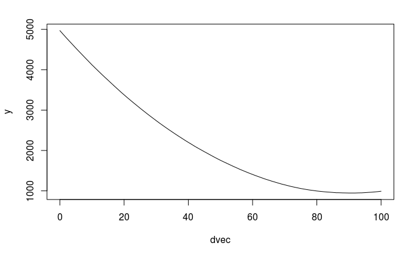

```r
rpred = function(n,ap,bp){
  #simuler la loi prédictive directement
  p = rbeta(n,ap,bp)
  x = rbinom(n,N,p)
}
rho_new = function(x,d){
  ##on calcule directement un coût prédictif
  # return(mean(300*(d-x)*(d>x)+100*(x-d)*(x>d)))## cout 1
  return(mean(1000*(d>x)+100*(x-d)*(x>d)))## cout 2
}
nb = 10000##parm MC
x = rpred(nb,1,1)#hyperparam : 1,1 posterior uniforme, juste pour observer la concentration
dvec = 0:N
y = sapply(dvec,rho_new,x =x )
plot(dvec,y,"l")
```

Et en zoomant

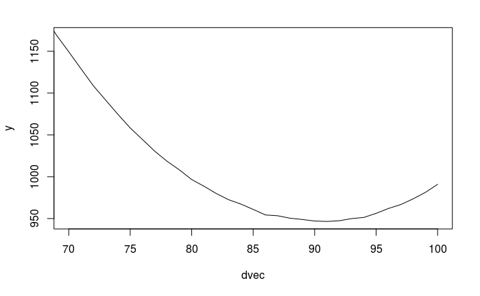

```r
plot(dvec,y,"l",xlim = c(70,100),ylim = range(y[70:100]))
```

Enfin, si l’on veut observer l’effet de l’estimation par MC des espérance, il suffit de faire le même calcul plusieurs fois :

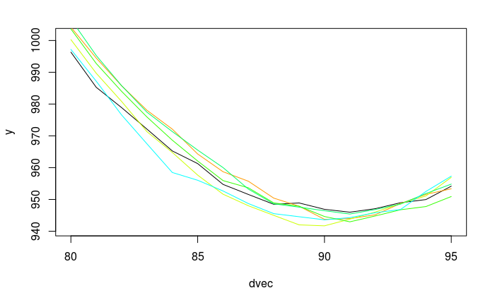

```r
nb = 10000##parm MC
lim = c(80,95)
dvec = lim[1]:lim[2]
nb_plot = 5
col_vec = rainbow(2*nb_plot)[1+(1:nb_plot)]
x = rpred(nb,1,1)#hyperparam : 1,1 posterior uniforme, juste pour observer la concentration
y = sapply(dvec,rho_new,x =x )
r = range(y)
di = diff(r)
plot(dvec,y,"l",ylim = c(r[1]-0.1*di,r[2]+0.1*di))
for (i in 1:nb_plot){
  x = rpred(nb,1,1)
  y = sapply(dvec,rho_new,x =x )
  lines(dvec,y ,col = col_vec[i])
}
```

*Voilà, et vous pouvez faire varier les paramètres pour observer ce qui vous chante (changer la fonction de coût, changer la fonction de simulation du posterior…).*

Un exemple : on change juste la taille de l’échantillon MC :

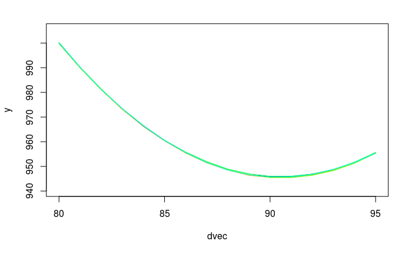

```r
nb = 1000000#paramMC : on multiplie par 100
lim = c(80,95)
dvec = lim[1]:lim[2]
nb_plot = 5
col_vec = rainbow(2*nb_plot)[1+(1:nb_plot)]
x = rpred(nb,1,1)#hyperparam : 1,1 posterior uniforme, juste pour observer la concentration
y = sapply(dvec,rho_new,x =x )
r = range(y)
di = diff(r)
plot(dvec,y,"l",ylim = c(r[1]-0.1*di,r[2]+0.1*di))
for (i in 1:nb_plot){
  x = rpred(nb,1,1)
  y = sapply(dvec,rho_new,x =x )
  lines(dvec,y ,col = col_vec[i])
}
```